# Cryptic_gating

```r
ggsave("markdown_images/Raver/unc qiaxcel examples.pdf", height = 5, width = 8, units="cm")
```

Now let’s analyse STMN2 in isolation

```r
stmn_csv <- paste0(data_dir, "Raver/qiaxcel of unc13a stmn2 aars1/4 targets 26th June/C220830A16_2023-06-27_2127_20230627_072754_Rw.csv")

df <- parse_qiaxcel_output(stmn_csv) %>%
  filter(Row %in% c("C", "D"))
```

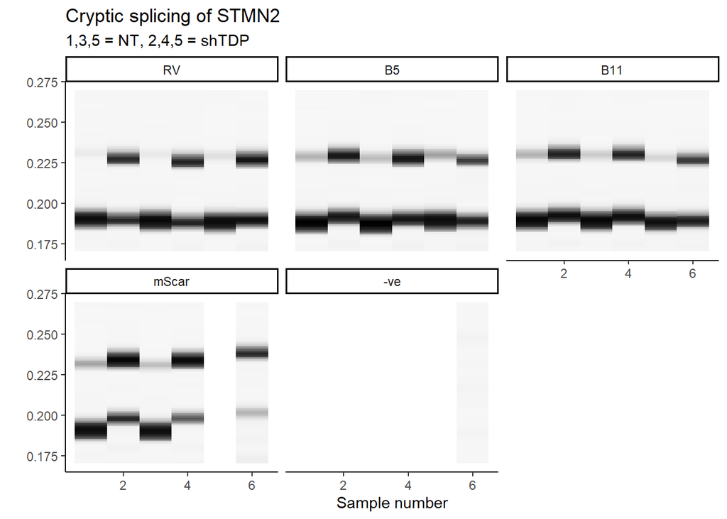

```r
df2 <- preprocess_dataframe(df %>%
                              filter(!is.na(value2)) %>%
                              mutate(value2 = as.numeric(value2)))

tweak_df <- data.frame(unique_id = c("C10", "D10", "D11", "D12"), shift = -0.008, multiply = 1)

df3 <- tweak_positions(df2, tweak_df)

df4 <- df3 %>%
  mutate(column = as.numeric(column)) %>%
  left_join(positions %>%
  mutate(row = ifelse(row == "A", "C", "D")), by = c("row","column")) %>%
  #distinct(row, column, plasmid, replicate, treatment) %>%
  mutate(actual_sample_no = ifelse(plasmid == "-ve", 6, 2*replicate - 1 + as.numeric(treatment == "shTDP")))

p1 <- ggplot(df4,
       aes(y = index_for_plotting, fill = corrected_value, x = actual_sample_no)) +
  geom_tile() +
  theme_classic() +
  scale_fill_gradient(low = "white", high = "black") +
  facet_wrap(~plasmid) +
  ggtitle("Cryptic splicing of STMN2", "1,3,5 = NT, 2,4,5 = shTDP") +
  xlab("Sample number") +
  ylab("") +
  ggeasy::easy_remove_legend() +
  ylim(0.17, 0.27)
p1
```

```r
stmn_final_data <- df4

yo <- find_molar_ratios(df3, lower_band_pos = 0.19, lower_band_width = 0.02, lower_band_nts = 155,
                        upper_band_pos= 0.23, upper_band_width = 0.02, upper_band_nts = 188) %>%
  left_join(positions %>%
              mutate(row = ifelse(row == "A", "C", "D")) %>%
              mutate(unique_id = paste0(row, column))) %>%
  filter(!is.na(replicate)) %>%
  ungroup() %>%
  group_by(plasmid, treatment) %>%
  mutate(psi = 100*(1-molar_fraction_lower_band)) %>%
  mutate(average_psi = mean(psi)) %>%
  mutate(sd_psi = sd(psi)) %>%
  mutate(good_names = factor(case_when(plasmid == "RV" ~ "Constitutive\nRaver",
                                plasmid == "B5" ~ "Cryptic\nRaver 6",
                                plasmid == "B11" ~ "Cryptic\nRaver 9",
                                plasmid == "mScar" ~ "mScarlet\ncontrol"),
         levels = c("mScarlet\ncontrol","Constitutive\nRaver","Cryptic\nRaver 6","Cryptic\nRaver 9")))
```

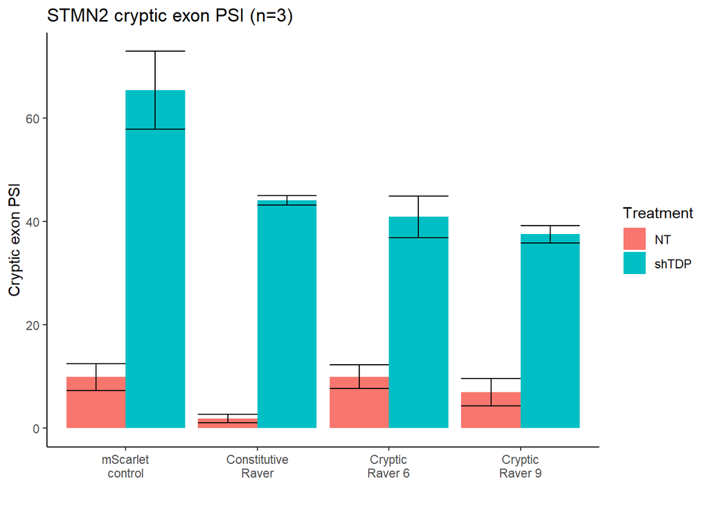

```r
stmn_ratios <- yo

p2 <- ggplot(yo %>% distinct(average_psi, .keep_all=T), aes(x = good_names, y = average_psi, fill = treatment)) +
  geom_bar(stat="identity", position= "dodge", alpha = 1) +
  ylab("Cryptic exon PSI") +
  geom_errorbar(aes(ymin = average_psi-sd_psi,
                            ymax = average_psi+sd_psi),
             position = position_dodge(width = 0.9)) +
  theme_classic() +
  ggtitle("STMN2 cryptic exon PSI (n=3)") +
  ggeasy::easy_add_legend_title("Treatment") +
  xlab("")
p2
```

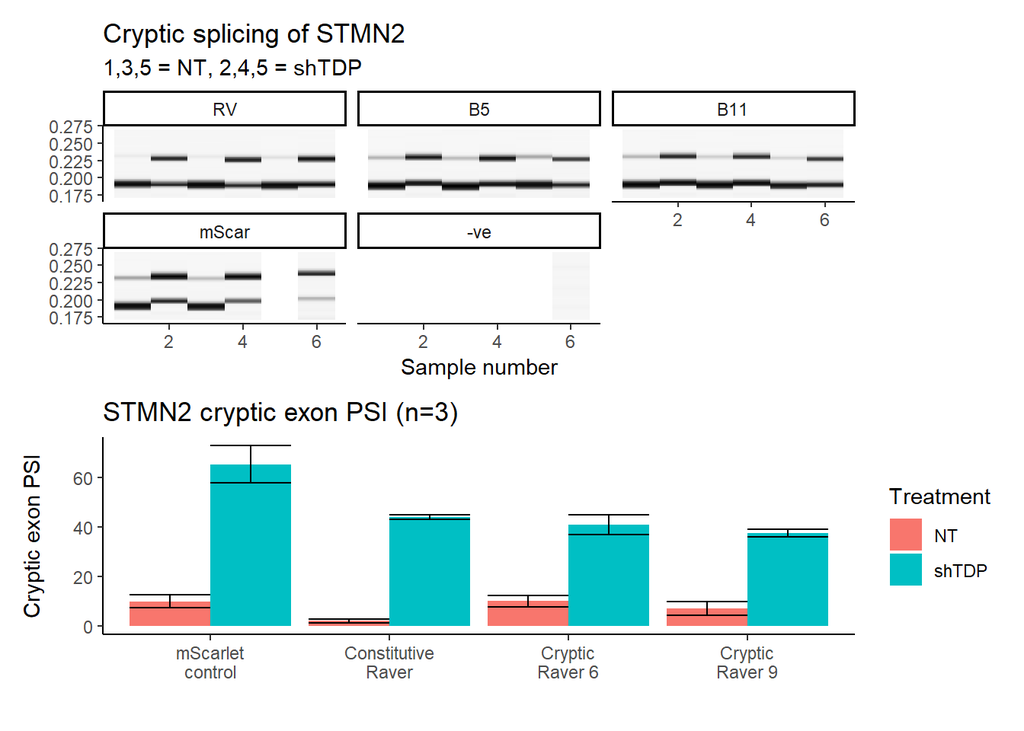

```r
p1 / p2
```

And now AARs1

```r
aars_csv <- paste0(data_dir, "Raver/qiaxcel of unc13a stmn2 aars1/aars1 3rd july/C220830A16_2023-07-04_2131_20230704_073449_Rw.csv")

df <- parse_qiaxcel_output(aars_csv)
```

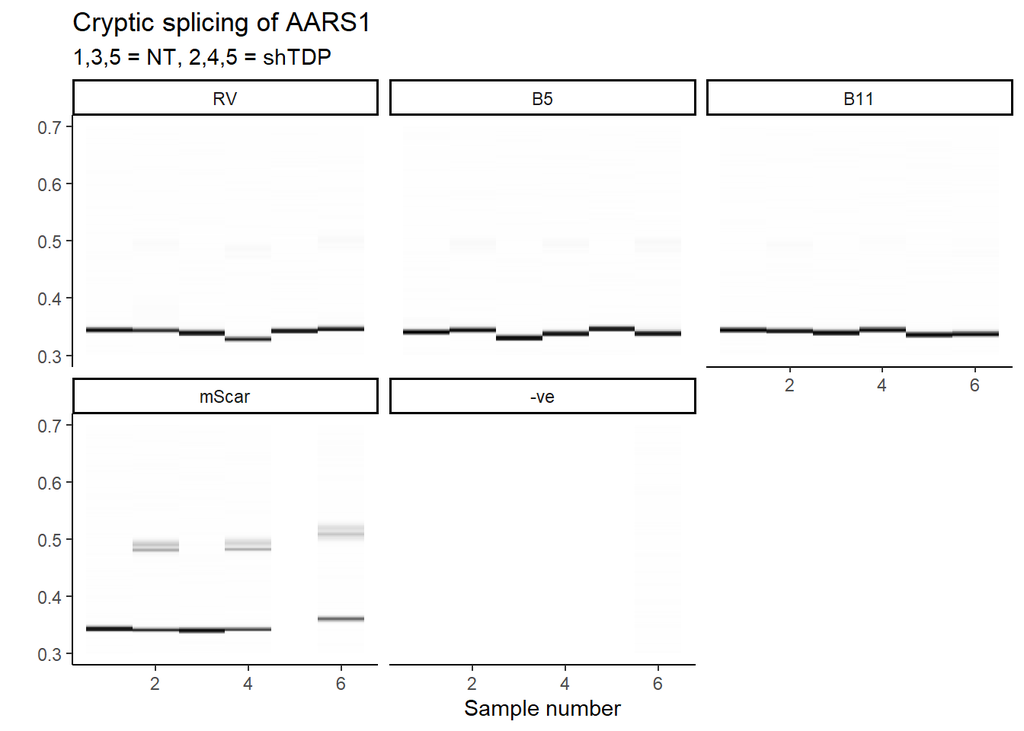

```r
df3 <- preprocess_dataframe(df)

df4 <- df3 %>%
  mutate(column = as.numeric(column)) %>%
  left_join(positions, by = c("row","column")) %>%
  mutate(actual_sample_no = ifelse(plasmid == "-ve", 6, 2*replicate - 1 + as.numeric(treatment == "shTDP")))

aars_final_data <- df4

p1 <- ggplot(df4,
       aes(y = index_for_plotting, fill = corrected_value, x = actual_sample_no)) +
  geom_tile() +
  theme_classic() +
  scale_fill_gradient(low = "white", high = "black") +
  facet_wrap(~plasmid) +
  ggtitle("Cryptic splicing of AARS1", "1,3,5 = NT, 2,4,5 = shTDP") +
  xlab("Sample number") +
  ylab("") +
  ylim(0.3, 0.7) +
  ggeasy::easy_remove_legend()
p1
```

```r
yo <- find_molar_ratios(df3, lower_band_pos = 0.35, lower_band_width = 0.05, lower_band_nts = 245,
                        upper_band_pos= 0.5, upper_band_width = 0.06, upper_band_nts = 245+87) %>%
  left_join(positions %>% mutate(unique_id = paste0(row, column))) %>%
  filter(!is.na(replicate)) %>%
  ungroup() %>%
  group_by(plasmid, treatment) %>%
  mutate(psi = 100*(1-molar_fraction_lower_band)) %>%
  mutate(average_psi = mean(psi)) %>%
  mutate(sd_psi = sd(psi)) %>%
  mutate(good_names = factor(case_when(plasmid == "RV" ~ "Constitutive\nRaver",
                                plasmid == "B5" ~ "Cryptic\nRaver 6",
                                plasmid == "B11" ~ "Cryptic\nRaver 9",
                                plasmid == "mScar" ~ "mScarlet\ncontrol"),
         levels = c("mScarlet\ncontrol","Constitutive\nRaver","Cryptic\nRaver 6","Cryptic\nRaver 9")))
```

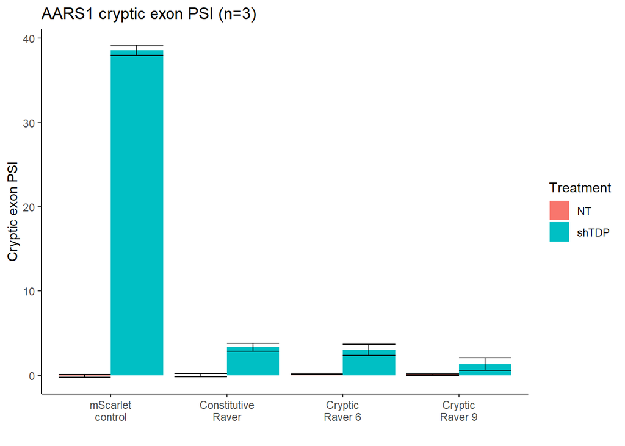

```r
aars_ratios <- yo

p2 <- ggplot(yo %>% distinct(average_psi, .keep_all=T), aes(x = good_names, y = average_psi, fill = treatment)) +
  geom_bar(stat="identity", position= "dodge", alpha = 1) +
  ylab("Cryptic exon PSI") +
  geom_errorbar(aes(ymin = average_psi-sd_psi,
                            ymax = average_psi+sd_psi),
             position = position_dodge(width = 0.9)) +
  theme_classic() +
  ggtitle("AARS1 cryptic exon PSI (n=3)") +
  ggeasy::easy_add_legend_title("Treatment") +
  xlab("")
p2
```

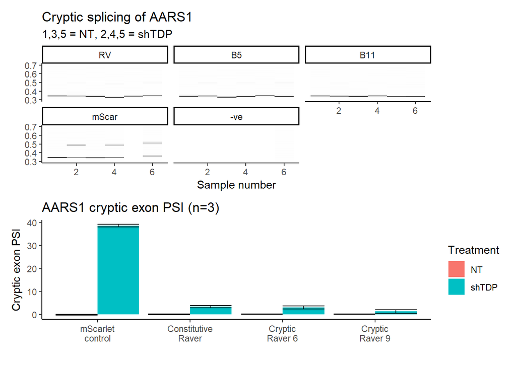

```r
p1 / p2
```

Now let’s make some nice summary plots

We’ll use smaller names so that it fits on the page

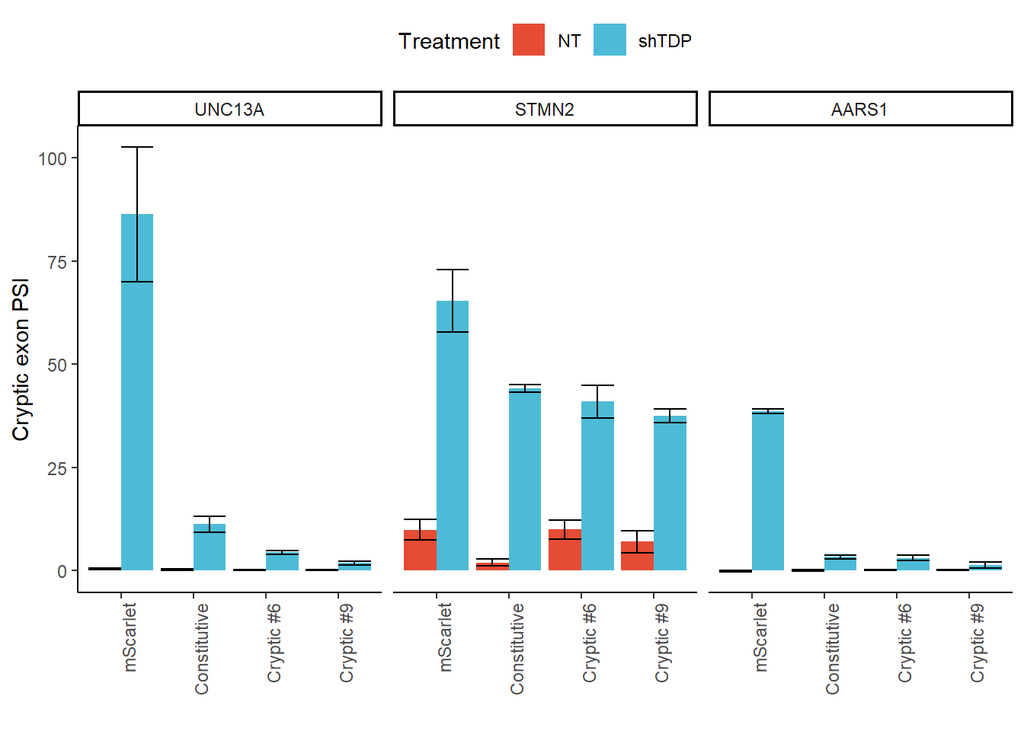

```r
triple_df <- bind_rows(aars_ratios %>%
                         mutate(target = "AARS1"),
                       bind_rows(unc_ratios %>% mutate(target = "UNC13A"),
                                 stmn_ratios %>% mutate(target = "STMN2"))) %>%
  ungroup() %>%
  mutate(target = factor(target, levels = c("UNC13A", "STMN2", "AARS1"))) %>%
  mutate(small_name = factor(case_when(good_names == "mScarlet\ncontrol" ~ "mScarlet",
                                good_names == "Constitutive\nRaver" ~ "Constitutive",
                                good_names == "Cryptic\nRaver 6" ~ "Cryptic #6",
                                good_names == "Cryptic\nRaver 9" ~ "Cryptic #9"),
                             levels = c("mScarlet", "Constitutive", "Cryptic #6", "Cryptic #9")))

ggplot(triple_df %>% distinct(average_psi, target, .keep_all=T), aes(x = small_name, y = average_psi, fill = treatment)) +
  geom_bar(stat="identity", position= "dodge", alpha = 1) +
  ylab("Cryptic exon PSI") +
  geom_errorbar(aes(ymin = average_psi-sd_psi,
                            ymax = average_psi+sd_psi),
             position = position_dodge(width = 0.9)) +
  theme_classic() +
  ggeasy::easy_add_legend_title("Treatment") +
  xlab("") +
  facet_wrap(~target) +
  ggeasy::easy_rotate_x_labels(side = "right") +
  ggsci::scale_fill_npg() +
  ggeasy::easy_legend_at("top")
```

```r
ggsave("markdown_images/Raver/unc aars and stmn barplot.pdf", height = 7, width = 9, units="cm")
```

### Let’s also plot the splicing of TDPREG raver itself

```r
csv <- paste0(data_dir, "Raver/WT autoregulation/C220830A16_2023-07-14_2133_20230714_064133_Rw.csv")

df <- parse_qiaxcel_output(csv)
```

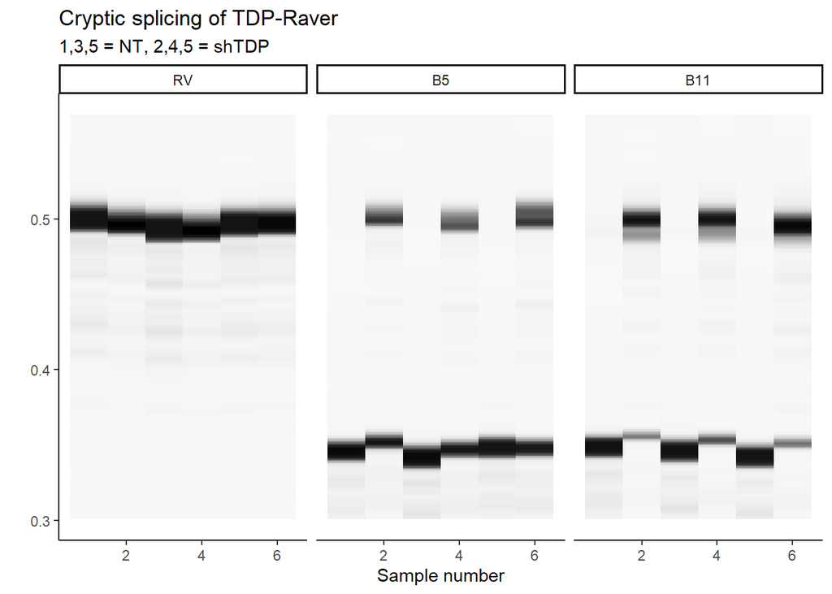

```r
df3 <- preprocess_dataframe(df)

df4 <- df3 %>%
  mutate(column = as.numeric(column)) %>%
  left_join(positions %>%
              mutate(row = ifelse(row == "D", "E", "A")), by = c("row","column")) %>%
  mutate(actual_sample_no = ifelse(plasmid == "-ve", 6, 2*replicate - 1 + as.numeric(treatment == "shTDP"))) %>%
  filter(plasmid %in% c("RV", "B5", "B11"))


p1 <- ggplot(df4,
       aes(y = index_for_plotting, fill = corrected_value, x = actual_sample_no)) +
  geom_tile() +
  theme_classic() +
  scale_fill_gradient(low = "white", high = "black") +
  facet_wrap(~plasmid) +
  ggtitle("Cryptic splicing of TDP-Raver", "1,3,5 = NT, 2,4,5 = shTDP") +
  xlab("Sample number") +
  ylab("") +
  ylim(0.3, 0.57) +
  ggeasy::easy_remove_legend()
p1
```

```r
yo <- find_molar_ratios(df3, lower_band_pos = 0.35, lower_band_width = 0.05, lower_band_nts = 335-91,
                        upper_band_pos= 0.5, upper_band_width = 0.05, upper_band_nts = 335) %>%
  left_join(positions %>%
              mutate(row = ifelse(row == "D", "E", "A"))
            %>% mutate(unique_id = paste0(row, column))) %>%
  filter(!is.na(replicate)) %>%
  ungroup() %>%
  group_by(plasmid, treatment) %>%
  mutate(psi = 100*(1-molar_fraction_lower_band)) %>%
  mutate(average_psi = mean(psi)) %>%
  mutate(sd_psi = sd(psi)) %>%
  mutate(good_names = factor(case_when(plasmid == "RV" ~ "Constitutive\nRaver",
                                plasmid == "B5" ~ "Cryptic\nRaver 6",
                                plasmid == "B11" ~ "Cryptic\nRaver 9",
                                plasmid == "mScar" ~ "mScarlet\ncontrol"),
         levels = c("mScarlet\ncontrol","Constitutive\nRaver","Cryptic\nRaver 6","Cryptic\nRaver 9")))  %>%
  filter(plasmid %in% c("RV", "B5", "B11"))
```

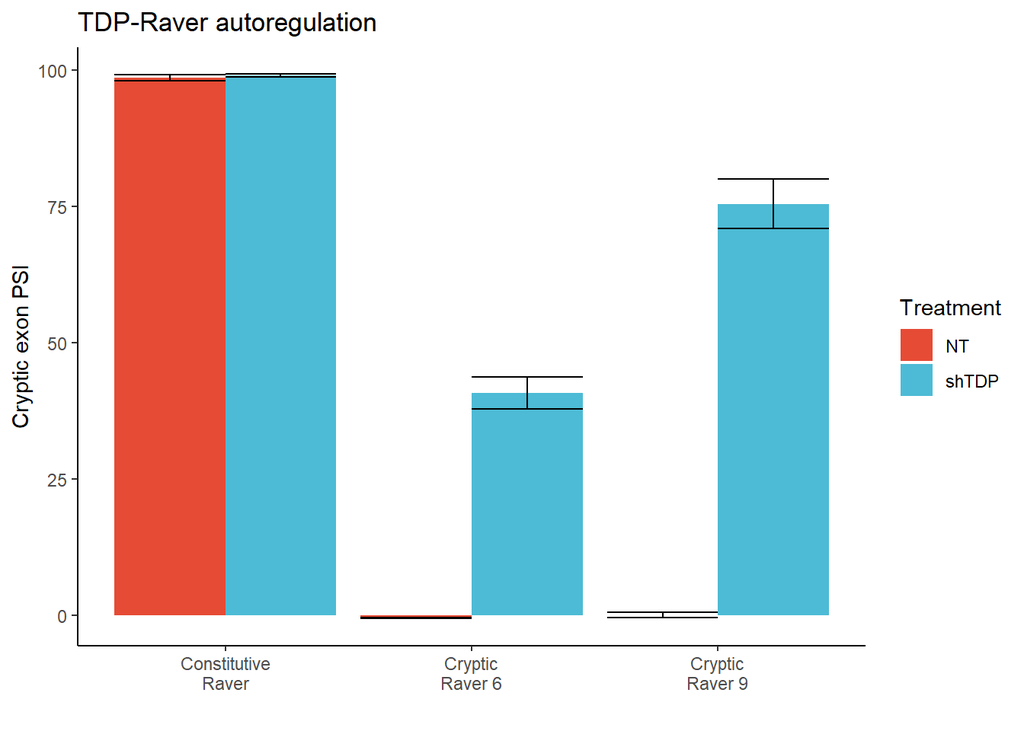

```r
p2 <- ggplot(yo %>% distinct(average_psi, .keep_all=T), aes(x = good_names, y = average_psi, fill = treatment)) +
  geom_bar(stat="identity", position= "dodge", alpha = 1) +
  ylab("Cryptic exon PSI") +
  geom_errorbar(aes(ymin = average_psi-sd_psi,
                            ymax = average_psi+sd_psi),
             position = position_dodge(width = 0.9)) +
  theme_classic() +
  ggtitle("TDP-Raver autoregulation") +
  ggeasy::easy_add_legend_title("Treatment") +
  xlab("") +
  ggsci::scale_fill_npg()

p2
```

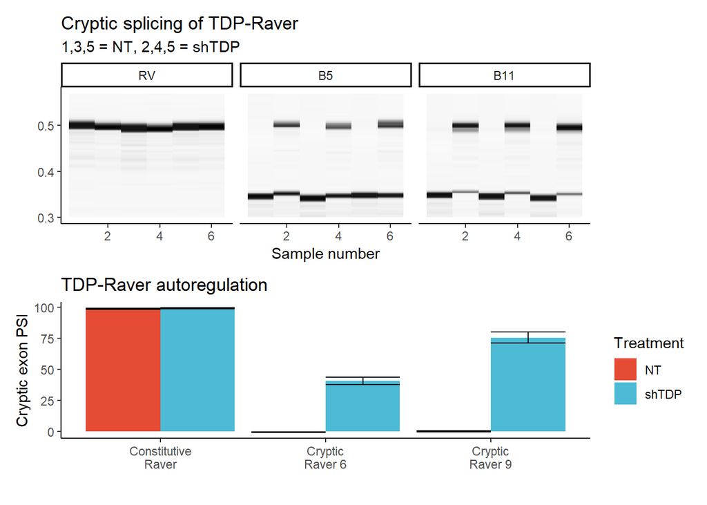

```r
p1 / p2
```

```r
ggsave("markdown_images/Raver/new autoregulation plot.pdf", height = 14, width = 14, units="cm")
```

### Growth competition

We put SKNBE2 cells with dox-inducible expression vectors for constitutive or TDP-REG-gated TDP/Raver (or BFP).

```r
gc_csv <- paste0(data_dir, "Raver/growth competition dream3/C220830A16_2023-07-15_2135_20230715_042136_Rw.csv")

df <- parse_qiaxcel_output(gc_csv)
```

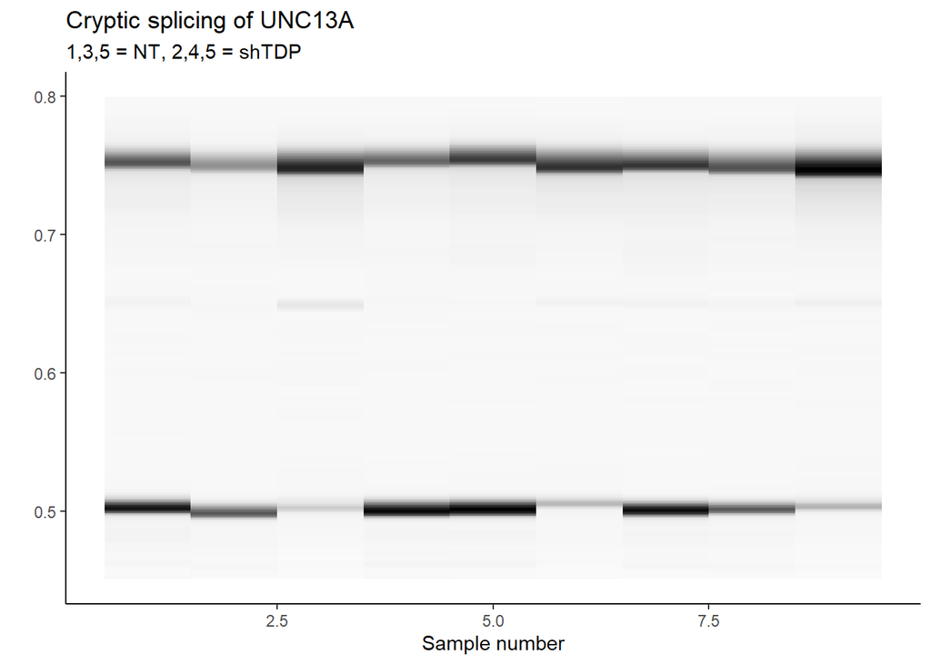

```r
df2 <- preprocess_dataframe(df)

#tweak_df <- data.frame(unique_id = "D12", shift = 0, multiply = 0.97)

#df3 <- tweak_positions(df2, tweak_df)
df3 <- df2  %>%
  filter(column < 10)

positions <- data.frame(row = "A", column = 1:9) %>%
  mutate(dox = c(0, 30, 1000, 0, 30, 1000, 0, 30, 1000),
         replicate = c(1, 1, 1, 2, 2, 2, 3, 3, 3))

df4 <- df3 %>%
  mutate(column = as.numeric(column)) %>%
  left_join(positions, by = c("row","column")) %>%
  mutate(actual_sample_no = column)

p1 <- ggplot(df4,
       aes(y = index_for_plotting, fill = corrected_value, x = actual_sample_no)) +
  geom_tile() +
  theme_classic() +
  scale_fill_gradient(low = "white", high = "black") +
  ylim(0.45,0.8) +
  ggtitle("Cryptic splicing of UNC13A", "1,3,5 = NT, 2,4,5 = shTDP") +
  xlab("Sample number") +
  ylab("") +
  ggeasy::easy_remove_legend()
p1
```

```r
yo <- find_molar_ratios(df3, lower_band_pos = 0.5, lower_band_width = 0.03, lower_band_nts = 335,
                        upper_band_pos= 0.75, upper_band_width = 0.03, upper_band_nts = 335+280) %>%
  left_join(positions %>% mutate(unique_id = paste0(row, column))) %>%
  ungroup() %>%
  group_by(dox) %>%
  mutate(pc_constitutive = 100*(molar_fraction_lower_band)) %>%
  mutate(mean_constitutive = mean(pc_constitutive)) %>%
  mutate(sd = sd(pc_constitutive)) %>%
  mutate(pc_cryptic = 100-pc_constitutive)
```

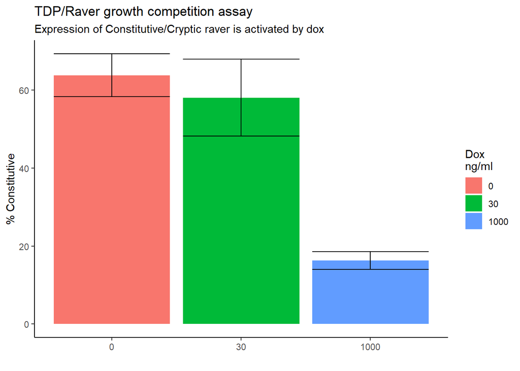

```r
p2 <- ggplot(yo %>% distinct(mean_constitutive, .keep_all=T), aes(x = factor(dox), y = mean_constitutive,
                                                                  fill = factor(dox))) +
  geom_bar(stat="identity", position= "dodge", alpha = 1) +
  ylab("% Constitutive") +
  geom_errorbar(aes(ymin = mean_constitutive-sd,
                            ymax = mean_constitutive+sd),
             position = position_dodge(width = 0.9)) +
  theme_classic() +
  ggtitle("TDP/Raver growth competition assay",
          "Expression of Constitutive/Cryptic raver is activated by dox") +
  ggeasy::easy_add_legend_title("Dox\nng/ml") +
  xlab("")
p2
```

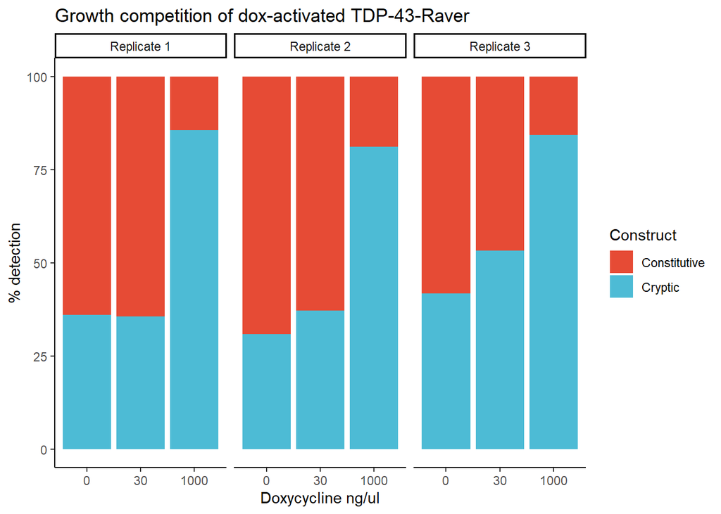

```r
stacked_df <- yo %>%
  dplyr::select(dox, replicate, pc_constitutive, pc_cryptic) %>%
  pivot_longer(cols = contains("pc_"))

ggplot(stacked_df, aes(x = factor(dox), y = value, fill = str_replace(name, "pc_c", "C"))) +
  geom_bar(stat="identity") +
  facet_wrap(~paste0("Replicate ", replicate)) +
  theme_classic() +
  xlab("Doxycycline ng/ul") +
  ylab("% detection") +
  ggeasy::easy_add_legend_title("Construct") +
  ggtitle("Growth competition of dox-activated TDP-43-Raver") +
  ggsci::scale_fill_npg()
```

```r
ggsave("markdown_images/Raver/growth competition plot.pdf", height = 7, width = 14, units="cm")
```

and now let’s analyse the Nanopore as obviously this is more informative

```r
bams <- Sys.glob(paste0(data_dir, "Raver/growth competition dream3/aligned/*.bam"))

for(bam in bams){

  file <- word(word(bam, 2, sep="barcodes_"), 1, sep="\\.bam")

  df <- data.frame(scanBam(bam)) %>%
    filter(flag < 256) %>%
    group_by(rname) %>%
    mutate(n = n()) %>%
    select(n) %>%
    unique() %>%
    mutate(combo = file)

  if(bam == bams[1]){
    all_df <- df
  } else {
    all_df <- bind_rows(all_df, df)
  }
}
```

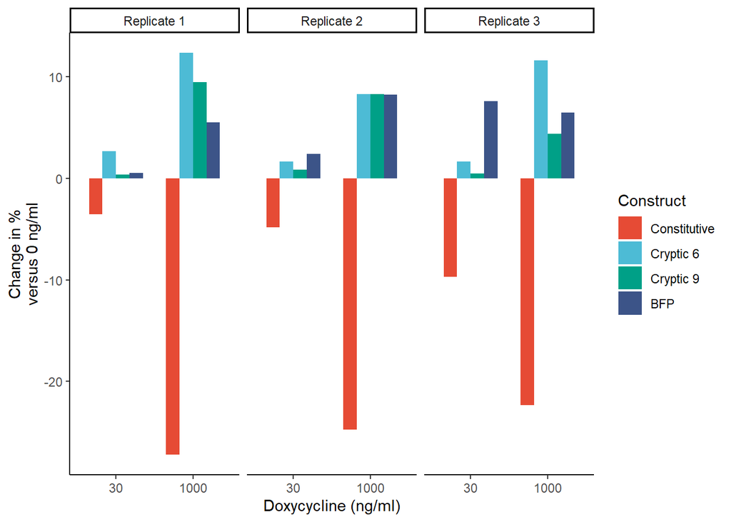

```r
all_df2 <- all_df %>%
  filter(!is.na(rname)) %>%
  mutate(replicate = case_when(combo < 4 ~ 1,
                               combo < 7 ~ 2,
                               T ~ 3)) %>%
  mutate(dox = factor(case_when(combo %in% c(1,4,7) ~ 0,
                         combo %in% c(2,5,8) ~ 30,
                         combo %in% c(3,6,9) ~ 1000),
                      levels = c(0, 30, 1000))) %>%
  ungroup() %>%
  group_by(replicate, dox) %>%
  mutate(pc = 100*n/sum(n)) %>%
  mutate(good_replicate = paste0("Replicate ", replicate),
         good_rname = factor(case_when(rname == "Dream1_rv_constitutive" ~ "Constitutive",
                                rname == "Dream1_rv_b5" ~ "Cryptic 6",
                                rname == "Dream1_rv_b11" ~ "Cryptic 9",
                                rname == "BFP" ~ "BFP"),
                             levels = c("Constitutive", "Cryptic 6",
                                        "Cryptic 9", "BFP")))
all_df3 <- all_df2 %>%
  ungroup() %>%
  group_by(good_replicate, good_rname) %>%
  mutate(dox0_pc = max(ifelse(dox == 0, pc, -1))) %>%
  mutate(change_pc = pc - dox0_pc)


p1 <- ggplot(all_df2 %>% ungroup(), aes(x = dox, y = pc, colour = good_rname)) +
  geom_line(aes(group = good_rname)) +
  geom_point() +
  facet_wrap(~good_replicate) +
  theme_classic() +
  ylim(0,NA) +
  ggeasy::easy_remove_legend() +
  ylab("% detected") +
  xlab("Doxycycline (ng/ml)") +
  ggsci::scale_colour_npg()

p2 <- ggplot(all_df3 %>% filter(dox != 0), aes(x = dox, y = change_pc, fill = good_rname)) +
  geom_bar(stat="identity", position = "dodge", width=0.7) +
  facet_wrap(~good_replicate) +
  theme_classic() +
  ggeasy::easy_add_legend_title("Construct") +
  ylab("Change in %\nversus 0 ng/ml") +
  xlab("Doxycycline (ng/ml)") +
  ggsci::scale_fill_npg()

p2
```

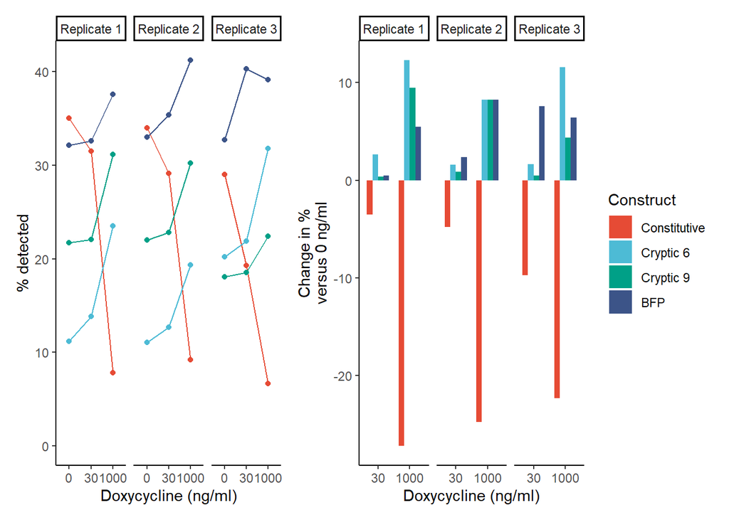

```r
p1 | p2
```

```r
ggsave("markdown_images/Raver/growth competition summary nanopore.pdf",
       height = 6, width = 19, units="cm")
```

# Specificity of AARS1

First let’s look at cell lines

```r
df <- read_csv("small_data_files/aars1 specificity/cell_line_counts_psi.csv.gz") %>%
  filter(!str_detect(experiment, "FAC")) %>%
  mutate(ce_psi = 100*ce_psi) %>%
  mutate(condition = ifelse(condition == "control", "Control", "TDP-43 -ve")) %>%
  group_by(experiment, condition) %>%
  mutate(average_ce = mean(ce_psi),
         sd_ce = sd(ce_psi)) %>%
  mutate(experiment = str_replace_all(experiment, "-", "\n")) %>%
  mutate(experiment = str_replace_all(experiment, "SH\n", "SH-"))
```

```r
summary <- df %>%
  distinct(experiment, condition, average_ce, sd_ce)

cell_line_plot <- ggplot(summary, aes(x = experiment, y = average_ce, fill = condition)) +
  geom_bar(position = "dodge", stat="identity") +
  theme_classic() +
    geom_errorbar(data = summary, aes(ymin = average_ce - sd_ce, ymax = average_ce + sd_ce),
                width = 0.2, position = position_dodge(width = 0.8)) +
  geom_point(data = df, aes(x = experiment, y = ce_psi, colour = "grey50", alpha = 0.1),
             position = position_dodge(width = 0.8)) +
  scale_fill_npg() +
  scale_color_identity() +
  ylab("% AARS1 CE inclusion") +
  xlab("") +
  ggeasy::easy_remove_legend_title() +
  ggtitle("AARS1 CE detection in cell lines")
```

now let’s look at patient samples

```r
df <- read_csv("small_data_files/aars1 specificity/aars1_ce_in_nygc.csv.gz") %>%
  dplyr::select(individual, sample, psi, tissue_clean, disease, type, tdp_path, disease_full) %>%
  mutate(psi = 100*psi) %>%
  pivot_wider(values_from = "psi", names_from = type) %>%
  mutate(psi = 0.5*(novel_acceptor + novel_donor)) %>%
  group_by(tissue_clean) %>%
  mutate(can_be_path = n_distinct(tdp_path) == 2) %>%
  filter(can_be_path) %>%
  mutate(tdp_disease = ifelse(disease %in% c("ALS-TDP", "FTD-TDP"), "Yes", "No"))
```

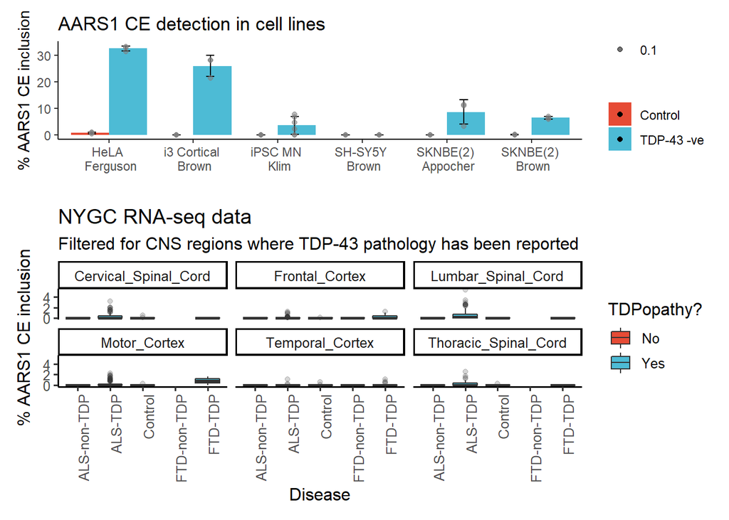

```r
nygc_plot <- ggplot(df, aes(x = disease, y = psi, fill = tdp_disease)) +
  geom_boxplot(outlier.alpha = 0.2) +
  facet_wrap(~tissue_clean) +
  ggpubr::theme_classic2() +
  ggeasy::easy_rotate_x_labels(side = "right") +
  ggeasy::easy_add_legend_title("TDPopathy?") +
  ggtitle("NYGC RNA-seq data",
          "Filtered for CNS regions where TDP-43 pathology has been reported") +
  xlab("Disease") +
  ylab("% AARS1 CE inclusion") +
  scale_fill_npg()

cell_line_plot / nygc_plot
```

```r
ggsave("markdown_images/AARS1 specificity/combined_plot.pdf",
       height = 20, width = 17, units="cm")
```